# Yifan’s HW4 for Stat418

Yifan Sun (UID:404878273)

May 24, 2017

## Introduction.

In the assignment, the data of [“Census Income”](https://archive.ics.uci.edu/ml/datasets/adult) was used to set up several models. It is “a set of reasonably clean records” (from the data set [description](https://archive.ics.uci.edu/ml/datasets/adult)) and has 14 attributes such as age, workclass, education, etc. For the assignment the column of income was considered to be the predicted variable (>50K or <=50K). The original rmd code and html result could be found on [github](https://github.com/pennysyf/Yifan-s-HW-for-Stats418/tree/master/HW4) and the README.md file would provide a direct link for the preview of html result.

This data has 48842 obversations and was spilted to be the **test and train datasets** with the ratio 4:6. The original data has two parts and in this assignment, I combined them into one dataset using function “rbind” and created a new csv file for later studies.

```r
adult1 <- read.table("~/adult.data", sep=",",header=F,col.names=c("age", "type_employer", "fnlwgt", "education",
                "education_num","marital", "occupation", "relationship", "race","sex",
                "capital_gain", "capital_loss", "hr_per_week","country", "income"),
        fill=FALSE,strip.white=T)
adult2 <- read.table("~/adult.test", sep=",",skip = 1, header=F,col.names=c("age", "type_employer", "fnlwgt", "education",
                "education_num","marital", "occupation", "relationship", "race","sex",
                "capital_gain", "capital_loss", "hr_per_week","country", "income"),
        fill=FALSE,strip.white=T)
adult2$income <- gsub(".","",adult2$income, fixed = TRUE)
adult <- rbind(adult1, adult2)
write.csv(adult, file = "adult.csv", row.names = FALSE)
```

The new dataset still has 14 attributes and the classification variable “income”.

```r
names(adult)
```

```
##  [1] "age"           "type_employer" "fnlwgt"        "education"
##  [5] "education_num" "marital"       "occupation"    "relationship"
##  [9] "race"          "sex"           "capital_gain"  "capital_loss"
## [13] "hr_per_week"   "country"       "income"
```

```r
head(adult, n = 5)
```

```
##   age    type_employer fnlwgt education education_num            marital
## 1  39        State-gov  77516 Bachelors            13      Never-married
## 2  50 Self-emp-not-inc  83311 Bachelors            13 Married-civ-spouse
## 3  38          Private 215646   HS-grad             9           Divorced
## 4  53          Private 234721      11th             7 Married-civ-spouse
## 5  28          Private 338409 Bachelors            13 Married-civ-spouse
##          occupation  relationship  race    sex capital_gain capital_loss
## 1      Adm-clerical Not-in-family White   Male         2174            0
## 2   Exec-managerial       Husband White   Male            0            0
## 3 Handlers-cleaners Not-in-family White   Male            0            0
## 4 Handlers-cleaners       Husband Black   Male            0            0
## 5    Prof-specialty          Wife Black Female            0            0
##   hr_per_week       country income
## 1          40 United-States  <=50K
## 2          13 United-States  <=50K
## 3          40 United-States  <=50K
## 4          40 United-States  <=50K
## 5          40          Cuba  <=50K
```

## Visualize the data.

#### Age.

It seems that the age variable would be a good predictor of income.

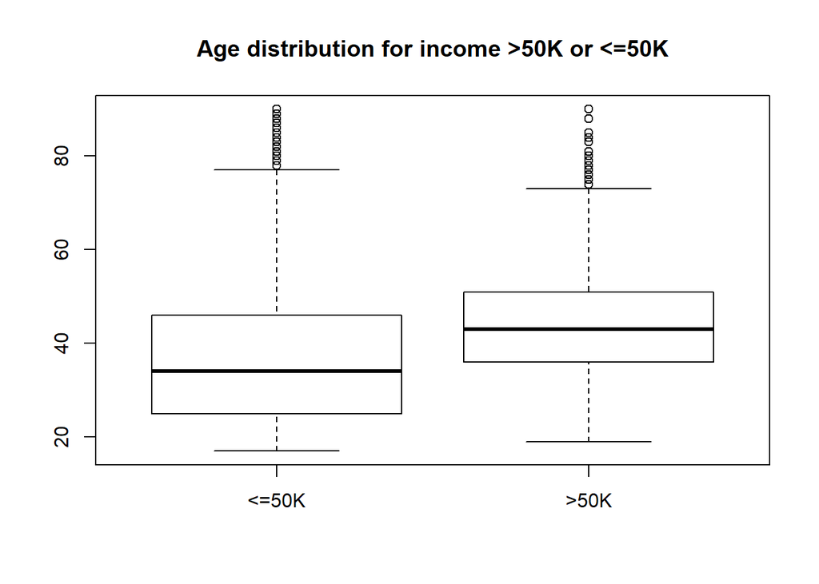

```r
boxplot(adult$age ~ adult$income, main = "Age distribution for income >50K or <=50K")
```

#### Type of employment variable.

It seems that the type_employer variable would be a good predictor of income.

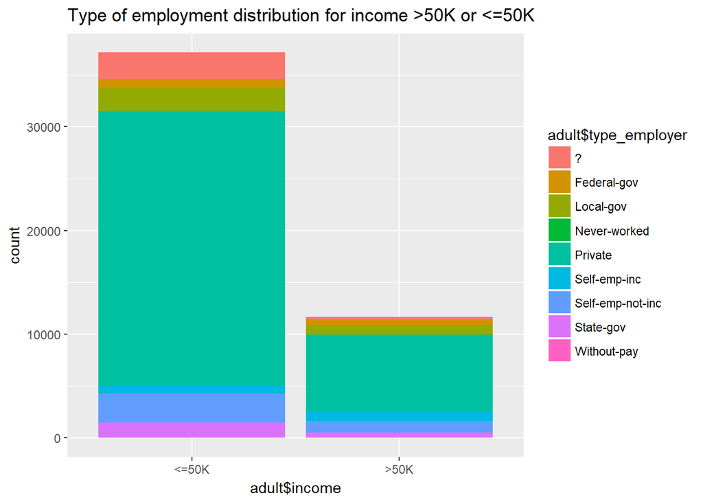

```r
library(ggplot2)
qplot(adult$income, fill = adult$type_employer, main = "Type of employment distribution for income >50K or <=50K")
```

#### Fnlwgt variable

It seems that the fnlwgt variable would not be a good predictor of income.

```r
summary(adult$fnlwgt)
```

```
##    Min. 1st Qu.  Median    Mean 3rd Qu.    Max.
##   12285  117551  178145  189664  237642 1490400
```

#### Education variable.

It seems that the education variable would be a good predictor of income.

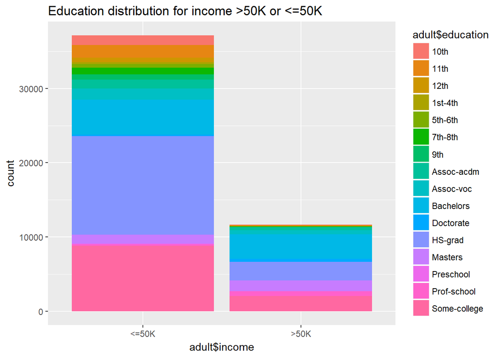

```r
qplot(adult$income, fill = adult$education, main = "Education distribution for income >50K or <=50K")
```

#### Number of education variable.

It seems that the education_num variable would be a good predictor of income.

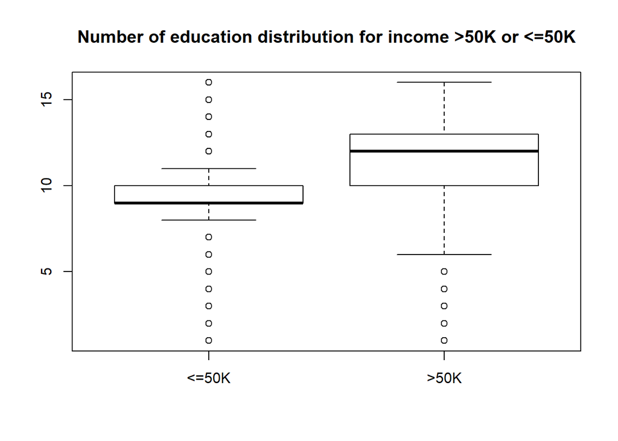

```r
boxplot(adult$education_num ~ adult$income, main = "Number of education distribution for income >50K or <=50K")
```

#### Marital variable.

It seems that the marital variable would be a good predictor of income.

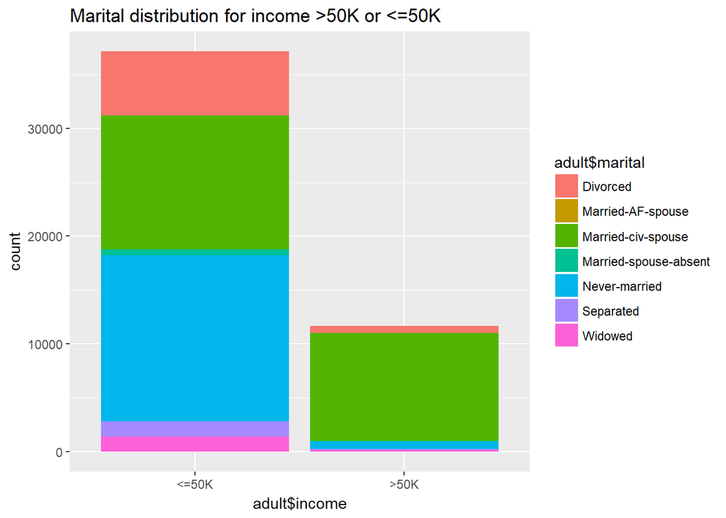

```r
qplot(adult$income, fill = adult$marital, main = "Marital distribution for income >50K or <=50K")
```

#### Occupation variable.

It seems that the occupation variable would be a good predictor of income.

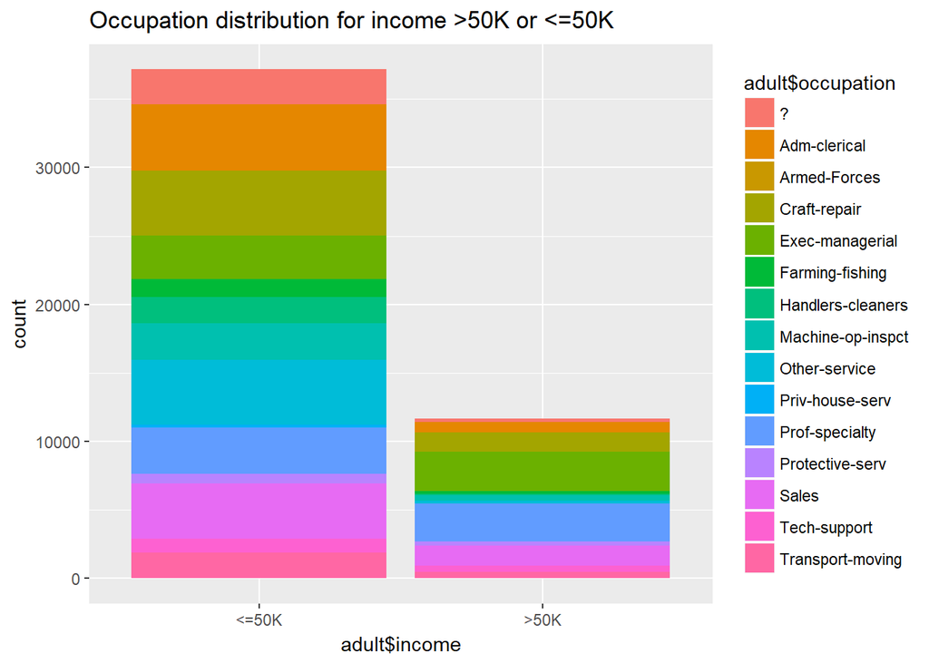

```r
qplot(adult$income, fill = adult$occupation, main = "Occupation distribution for income >50K or <=50K")
```

#### Relationship variable.

It seems that the relationship variable would be a good predictor of income.

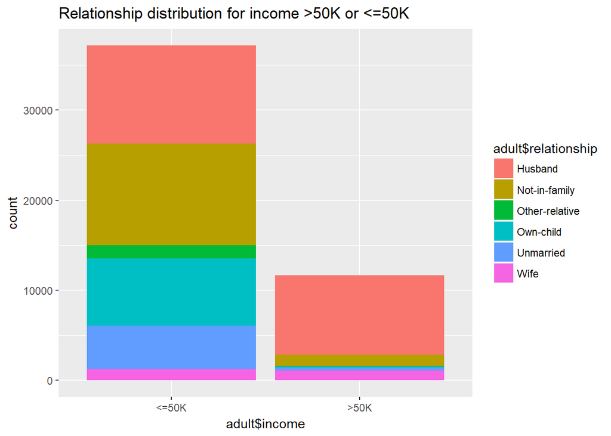

```r
qplot(adult$income, fill = adult$relationship, main = "Relationship distribution for income >50K or <=50K")
```

#### Race variable.

It seems that the race variable would be a good predictor of income.

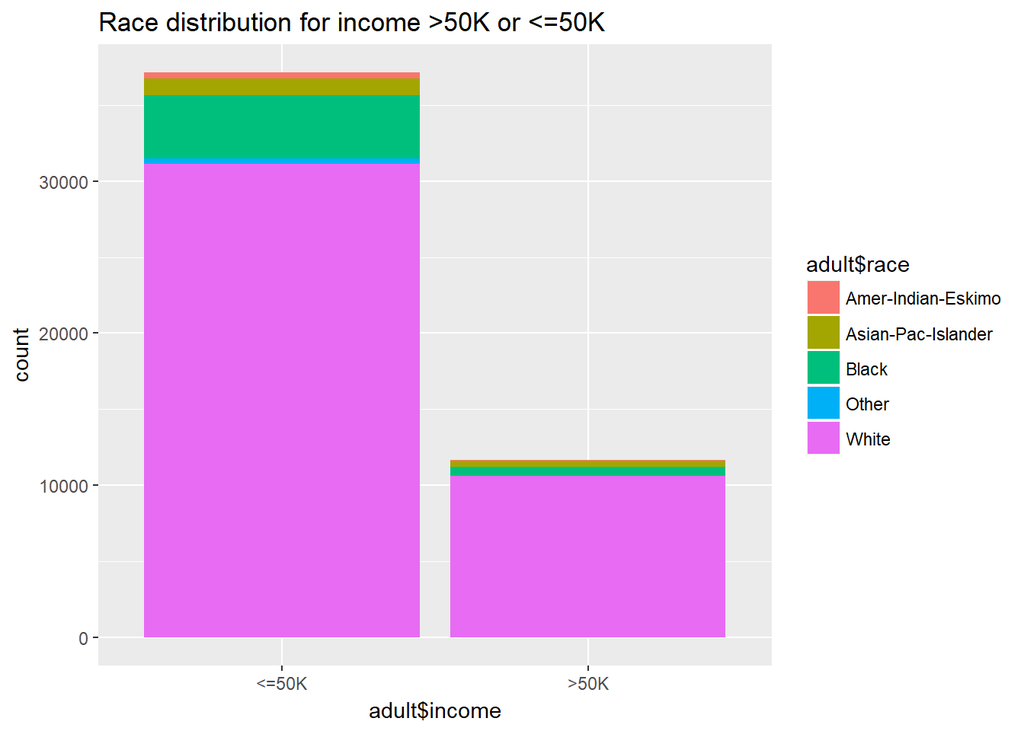

```r
qplot(adult$income, fill = adult$race, main = "Race distribution for income >50K or <=50K")
```

#### Sex variable.

```r
table(adult[,c("sex", "income")])
```

```
##         income
## sex      <=50K  >50K
##   Female 14423  1769
##   Male   22732  9918
```

#### Capital gain variable.

It seems that the capital_gain variable would not be a good predictor of income.

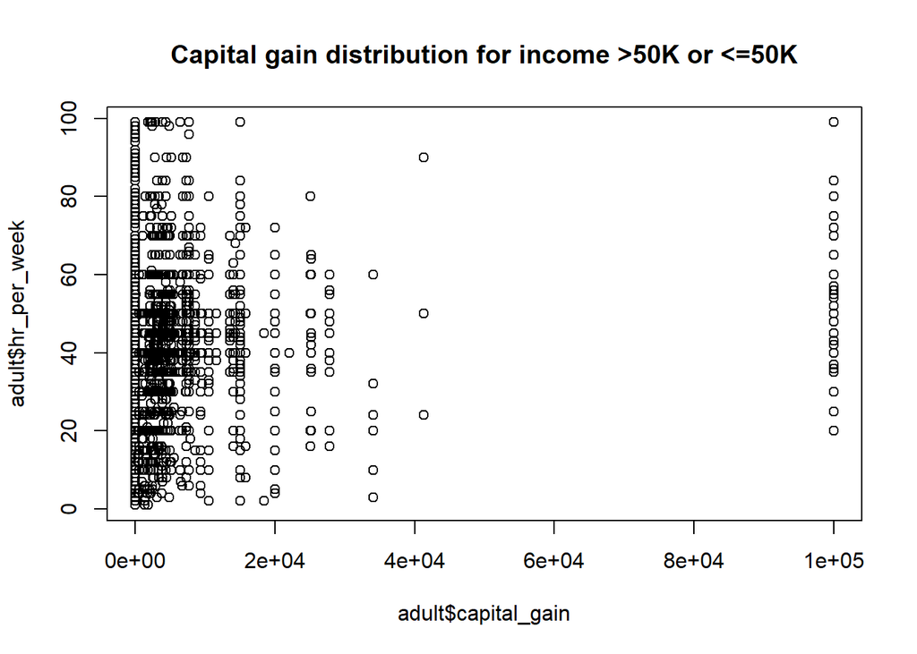

```r
plot(adult$hr_per_week ~ adult$capital_gain, main = "Capital gain distribution for income >50K or <=50K")
```

#### Capital loss variable.

It seems that the capital_loss variable would not be a good predictor of income.

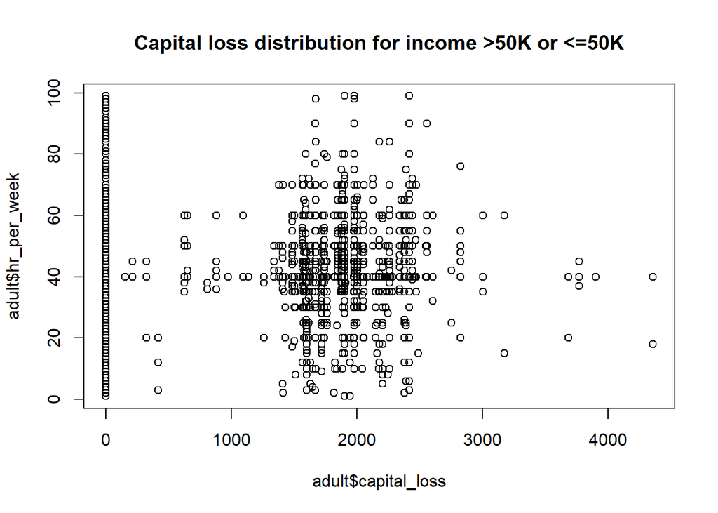

```r
plot(adult$hr_per_week ~ adult$capital_loss, main = "Capital loss distribution for income >50K or <=50K")
```

#### Hours per week variable.

It seems that the hr_per_week variable would be a good predictor of income.

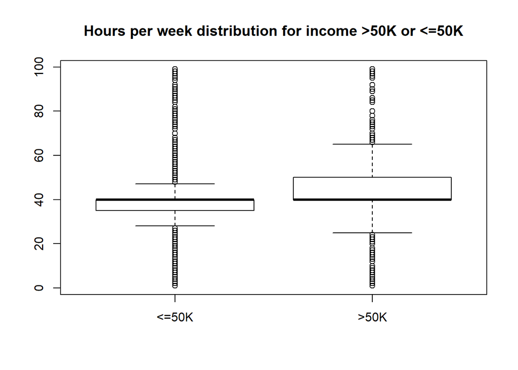

```r
boxplot(adult$hr_per_week ~ adult$income, main = "Hours per week distribution for income >50K or <=50K")
```

#### Country variable.

It seems that the country variable would be a good predictor of income.

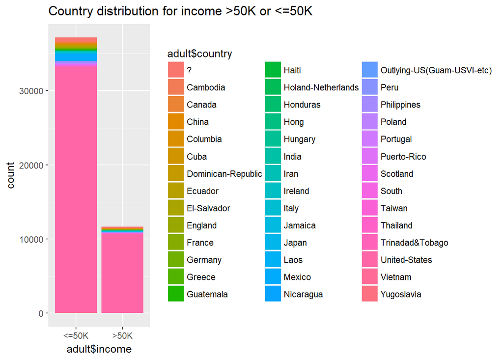

```r
qplot(adult$income, fill = adult$country, main = "Country distribution for income >50K or <=50K")
```

## Analysis of different models.

#### Logistic regression

From the [last assignment](https://htmlpreview.github.io/?https://github.com/pennysyf/Yifan-s-HW-for-Stats418/blob/master/HW3/Yifan_Sun_s_HW3.html), the bestlambda value is 0.0006523123.

The first model was using lambda = 0, the auc is 0.9058254,system time of elapsed is 0.45.

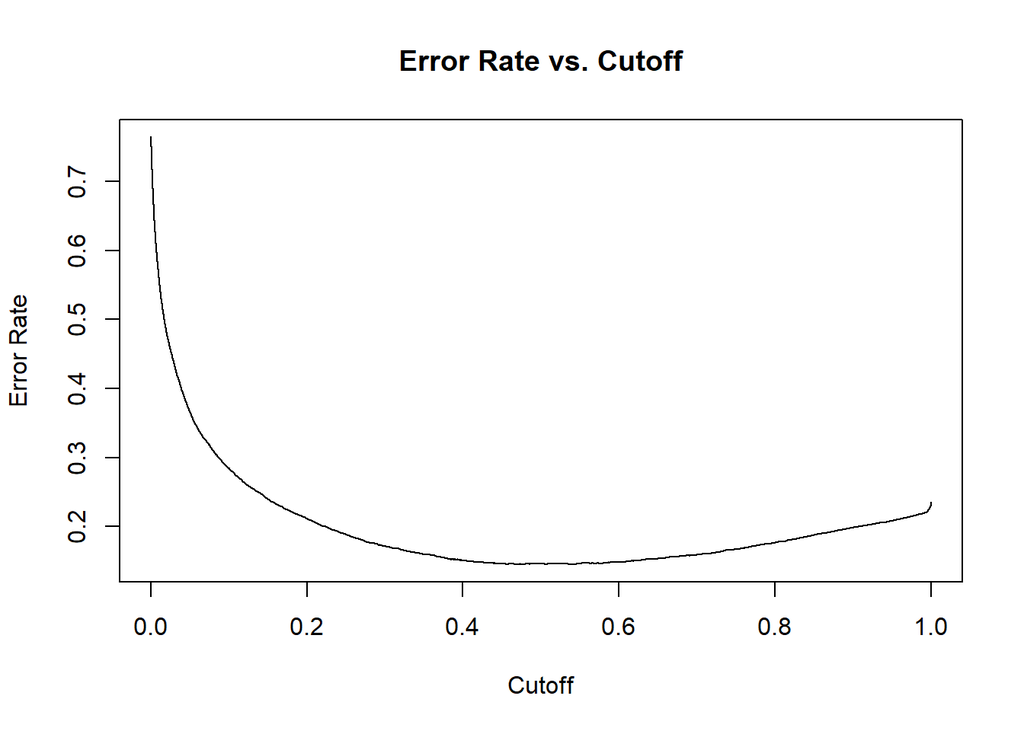

lambda = 0,Error Rate vs. Cutoff

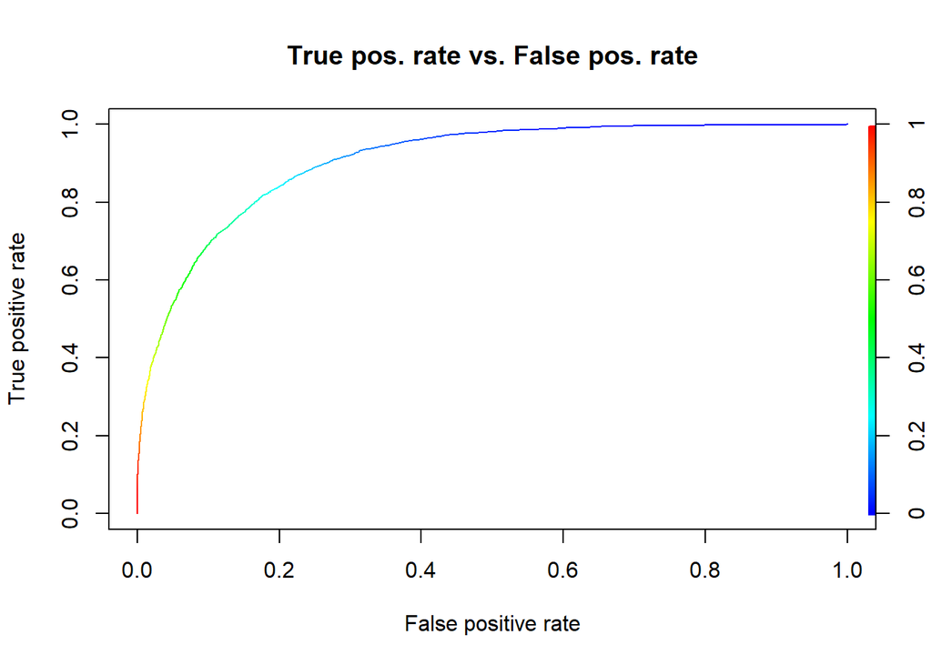

lambda = 0,True pos. rate vs. False pos. rate

The second model was using lambda = 0.1, the auc is 0.8518726, system time of elapsed is 0.03.

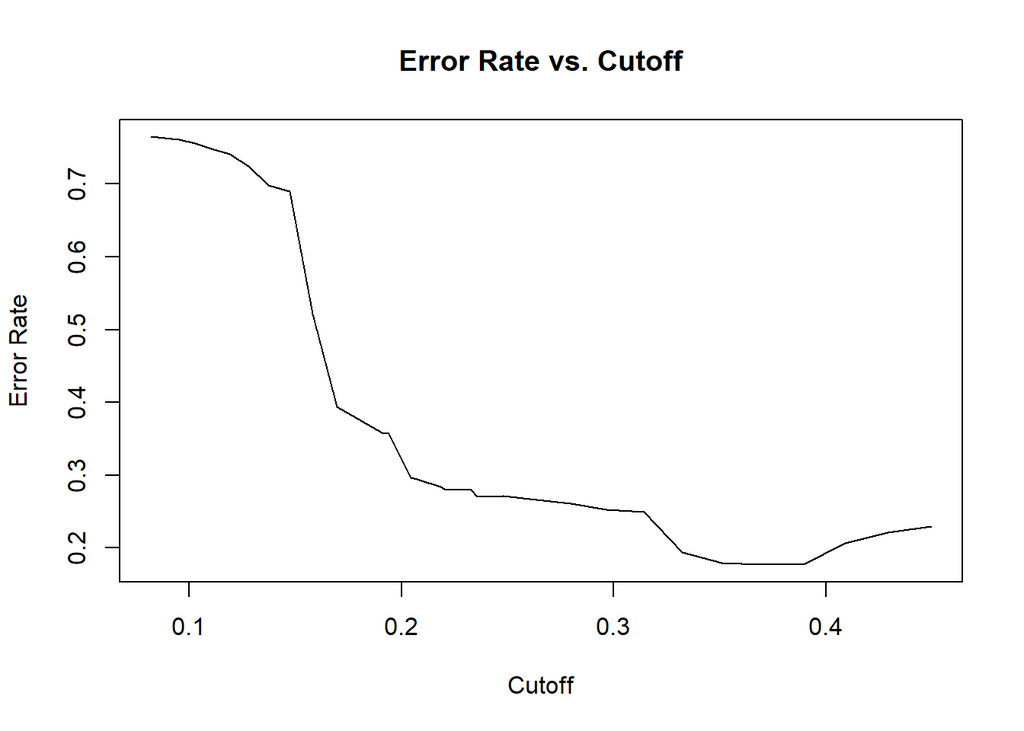

lambda = 0.1,Error Rate vs. Cutoff

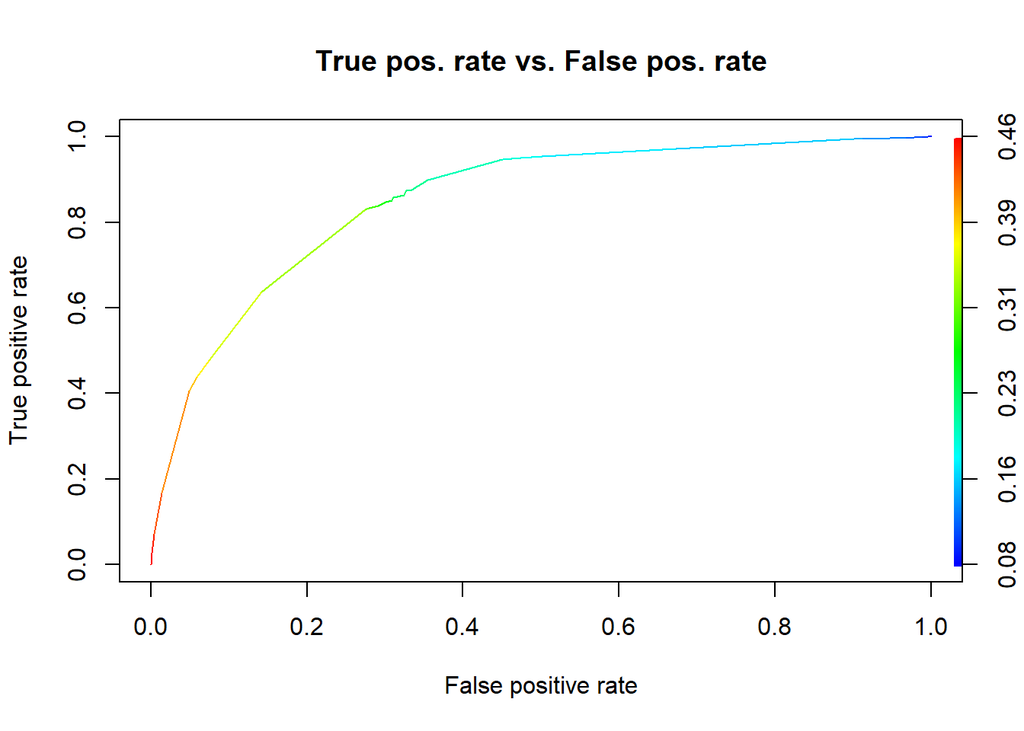

lambda = 0.1,True pos. rate vs. False pos. rate

The third model was using lambda = bestlambda, the auc is 0.9061721, system time of elapsed is 0.27.

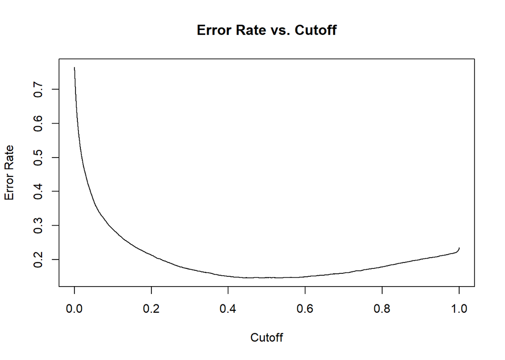

lambda = bestlambda,Error Rate vs. Cutoff

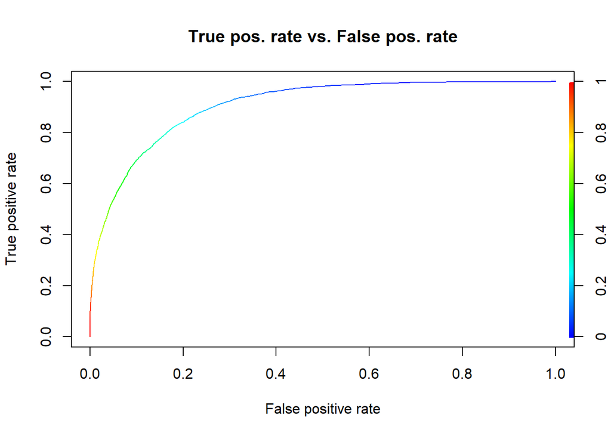

#####From the above models, when the lambda uses the best value we got from the cross-vaildation, the auc value becomes the highest among these and the system time is short, and we use the auc to check for goodness. The ROC curve shows the true pos. rate vs. the false pos. rate. (known as sensitivity and specificity, from [wikipedia](https://en.wikipedia.org/wiki/Sensitivity_and_specificity))

#### RF models

For the randomForest models, I tried some models with different parameters.

The first model has max_depth = 20, num_parallel_tree = 500. The train-rmse is 0.426952, the system time of elapsed is 9.17, the auc is 0.920182.

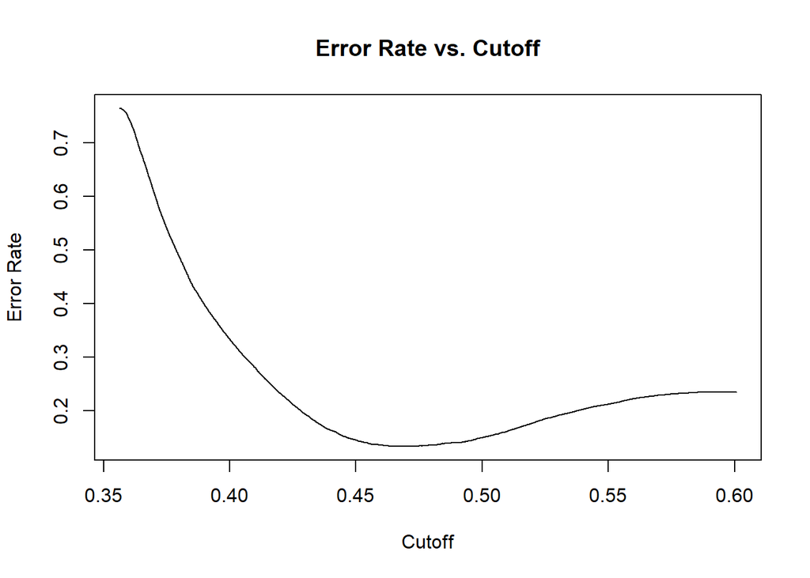

max_depth = 20,Error Rate vs. Cutoff

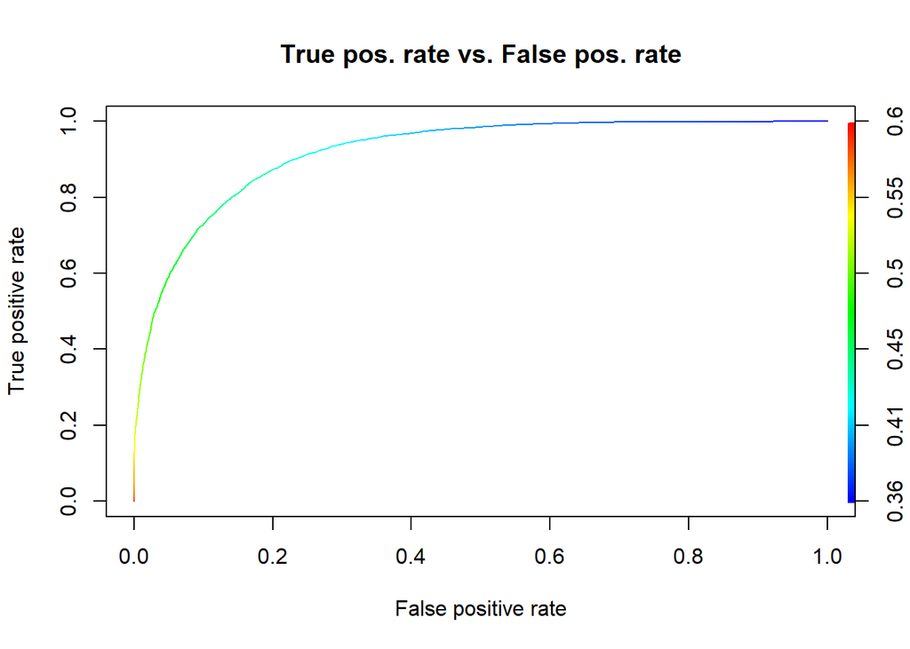

max_depth = 20,True pos. rate vs. False pos. rate

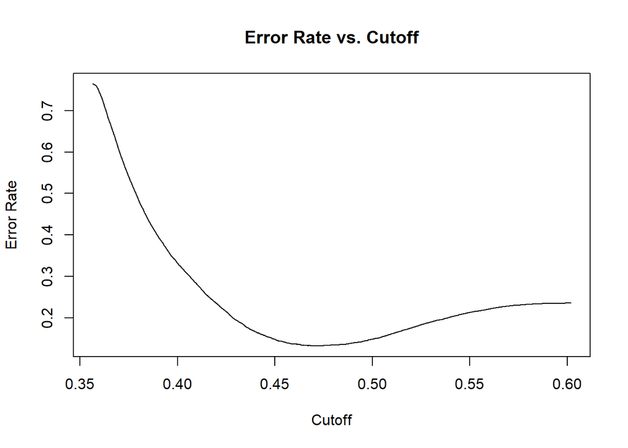

max_depth = 60,Error Rate vs. Cutoff

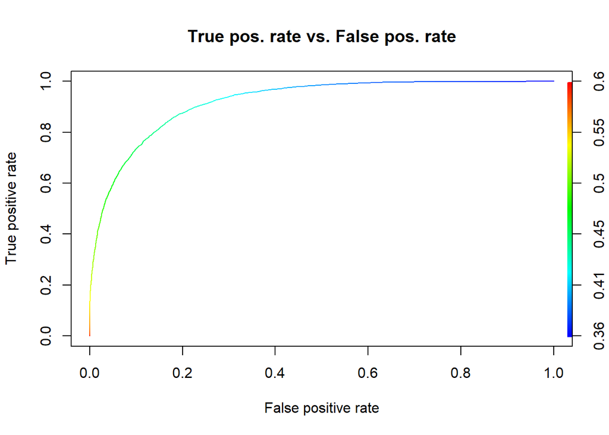

max_depth = 60,True pos. rate vs. False pos. rate

The third model has max_depth = 20, num_parallel_tree = 400. The train-rmse is 0.426290, the auc is 0.9182044.

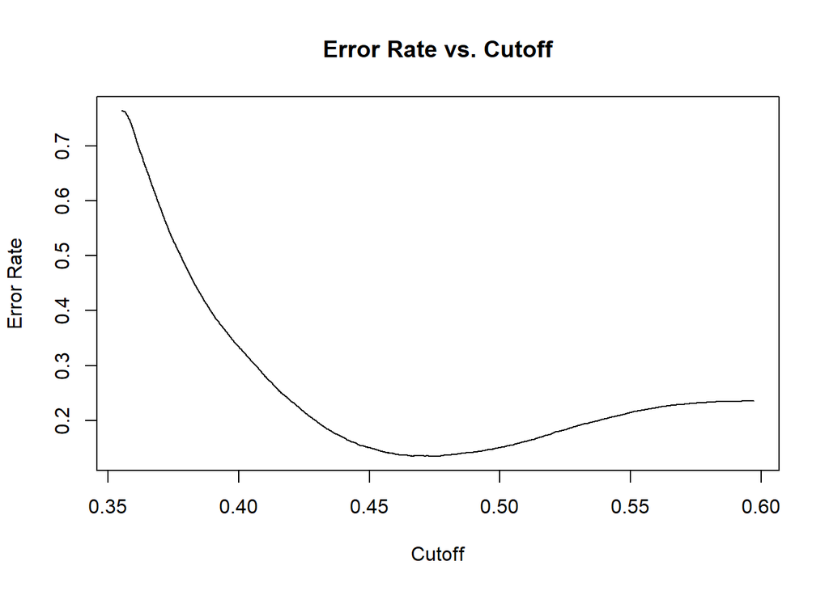

num_parallel_tree = 400,Error Rate vs. Cutoff

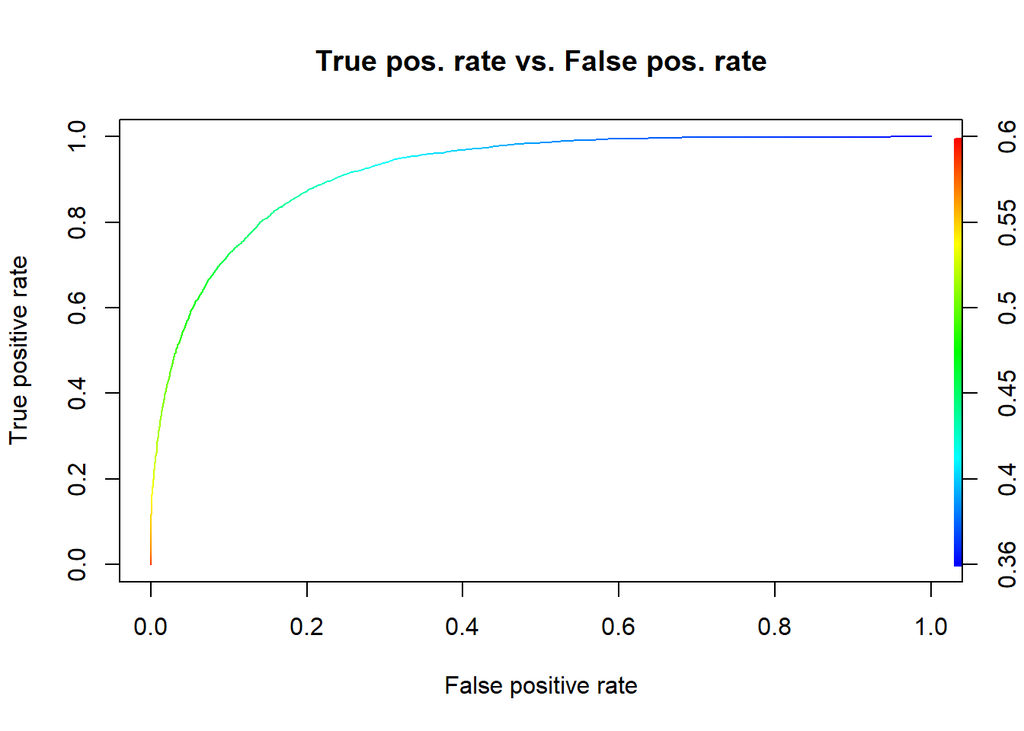

num_parallel_tree = 400,True pos. rate vs. False pos. rate

The first model has ntrees = 50, the accuracy of predicting income is 0.8271997, comparing to the auc = 0.919111 it is smaller.

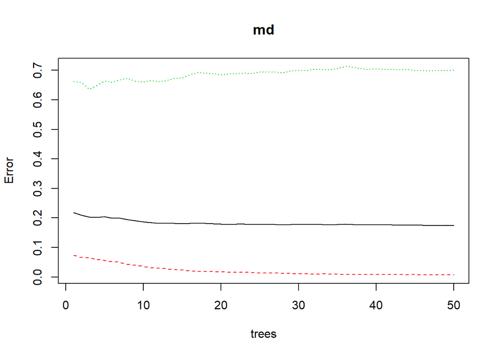

ntrees = 50

The second model has ntrees = 100, the accuracy of predicting income is 0.8255618, it is still smaller than the auc.

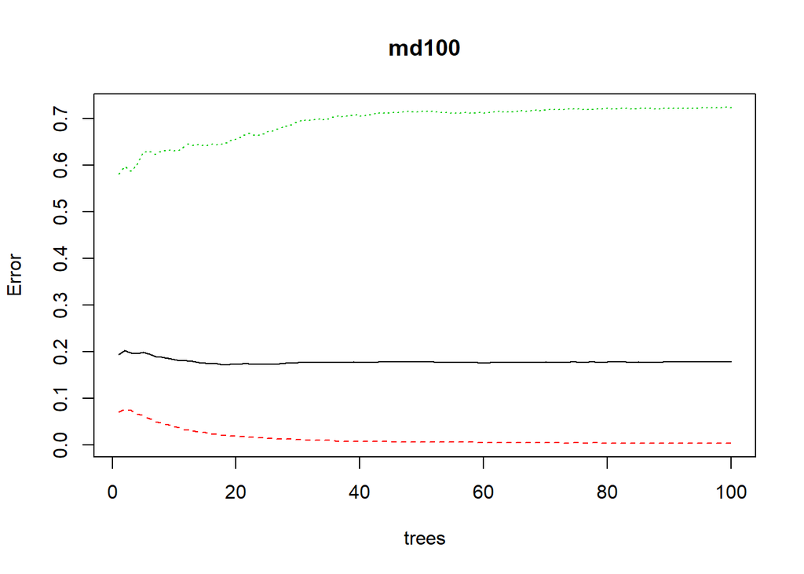

ntrees = 100

##### Wwe use the auc to check for goodness. The ROC curve shows the true pos. rate vs. the false pos. rate. (known as sensitivity and specificity, from [wikipedia](https://en.wikipedia.org/wiki/Sensitivity_and_specificity))

## GBM models

First Iused the function xgb.cv to find the best iteration = 46, this would be used as the value of parameter “nrounds”.

The first model has max_depth = 20, eta = 0.1. The system time of elapsed is 1.34, the auc is 0.919518.

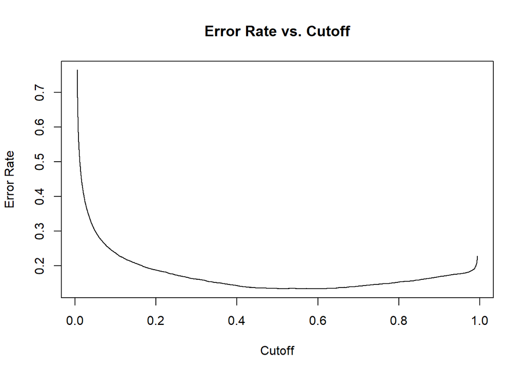

max_depth = 20, eta = 0.1, Error Rate vs. Cutoff

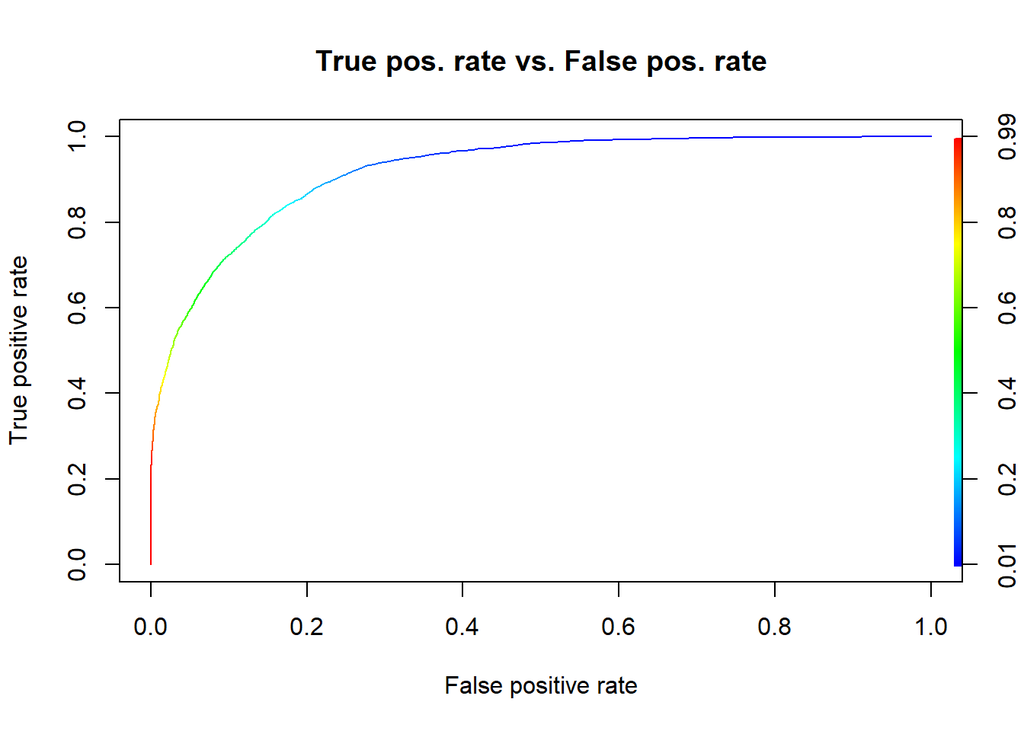

max_depth =20, eta = 0.1,True pos. rate vs. False pos. rate

The second model has max_depth = 20, eta = 0.3. The auc is 0.9172211.

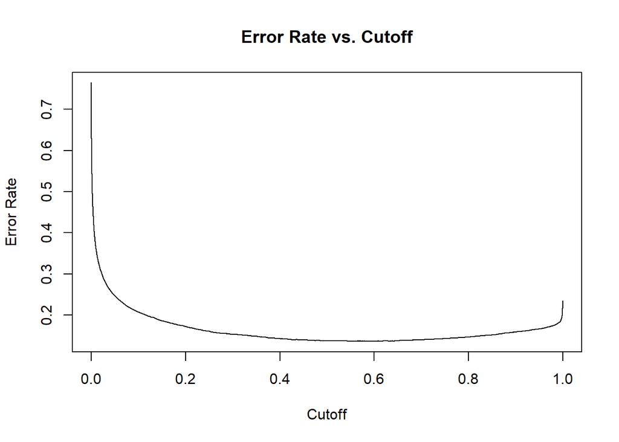

max_depth = 20, eta = 0.3, Error Rate vs. Cutoff

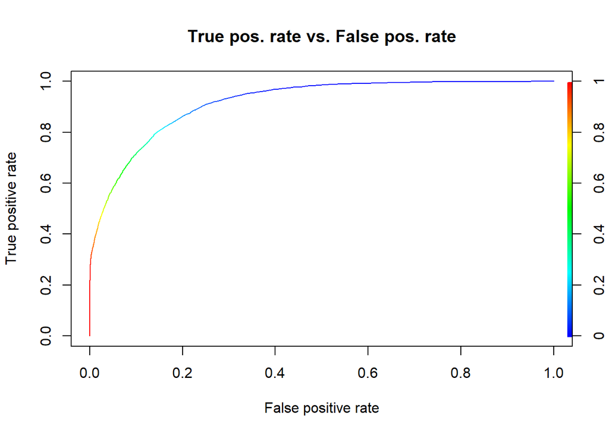

max_depth = 20, eta = 0.3,True pos. rate vs. False pos. rate

The third model has max_depth = 40, eta = 0.1. The auc is 0.9145575.

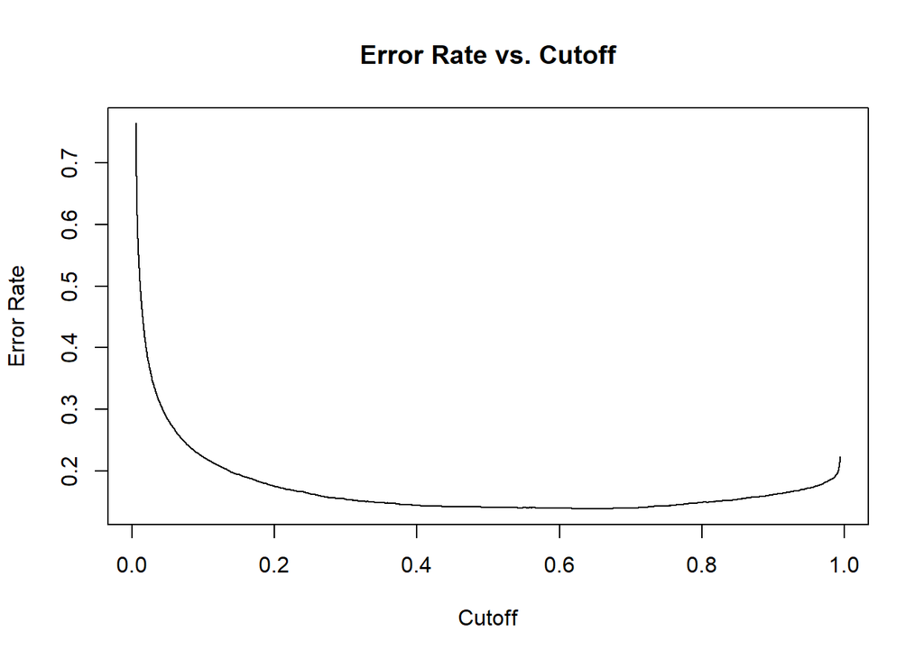

max_depth = 40, eta = 0.1, Error Rate vs. Cutoff

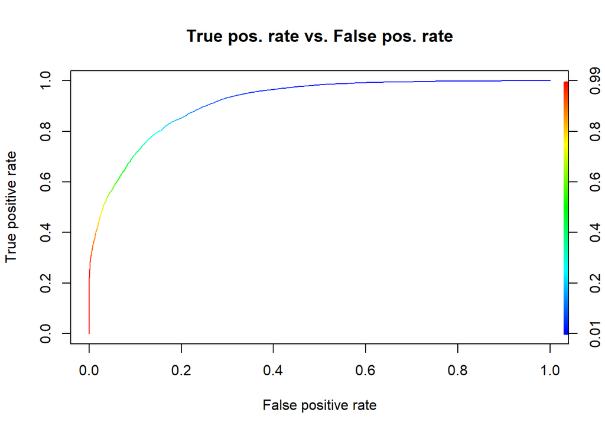

max_depth = 40, eta = 0.1,True pos. rate vs. False pos. rate

##### In order to maximize the value of auc, we tend to have a smaller depth of trees and smaller learning rate.

##### We use the auc to check for goodness. The ROC curve shows the true pos. rate vs. the false pos. rate. (known as sensitivity and specificity, from [wikipedia](https://en.wikipedia.org/wiki/Sensitivity_and_specificity))

## NN in h2o

#### Playing with the parameters. (activation, hidden, epochs, etc.)

```r
library(h2o)
h2o.init(nthreads=-1)
```

```
##  Connection successful!
##
## R is connected to the H2O cluster:
##     H2O cluster uptime:         1 hours 7 minutes
##     H2O cluster version:        3.10.4.6
##     H2O cluster version age:    1 month and 11 days
##     H2O cluster name:           H2O_started_from_R_Penny_mkc743
##     H2O cluster total nodes:    1
##     H2O cluster total memory:   2.76 GB
##     H2O cluster total cores:    8
##     H2O cluster allowed cores:  8
##     H2O cluster healthy:        TRUE
##     H2O Connection ip:          localhost
##     H2O Connection port:        54321
##     H2O Connection proxy:       NA
##     H2O Internal Security:      FALSE
##     R Version:                  R version 3.4.0 (2017-04-21)
```

```r
adultdata <- h2o.importFile("adult.csv")
set.seed(123)
N <- nrow(adult)
idx <- sample(1:N, 0.6*N)
adult_train <- adult[idx,]
adult_test <- adult[-idx,]
X <- Matrix::sparse.model.matrix(income ~ . - 1, data = adult)
X_train <- X[idx,]
X_test <- X[setdiff(1:N,idx),]
```

```r
dx_split <- h2o.splitFrame(adultdata, ratios = c(0.6,0.2), seed = 123)
dx_train <- dx_split[[1]]
dx_valid <- dx_split[[2]]
dx_test <- dx_split[[3]]
Xnames <- names(dx_train)[which(names(dx_train)!="income")]
system.time({
md <- h2o.deeplearning(x = Xnames, y = "income", training_frame = dx_train, validation_frame = dx_valid,
## DEFAULT: activation = "Rectifier", hidden = c(200,200),
epochs = 100, stopping_rounds = 2, stopping_metric = "AUC", stopping_tolerance = 0)})
```

```
##    user  system elapsed
##    0.27    0.02   26.61
```

```r
h2o.performance(md, dx_test)@metrics$AUC
```

```
## [1] 0.9113302
```

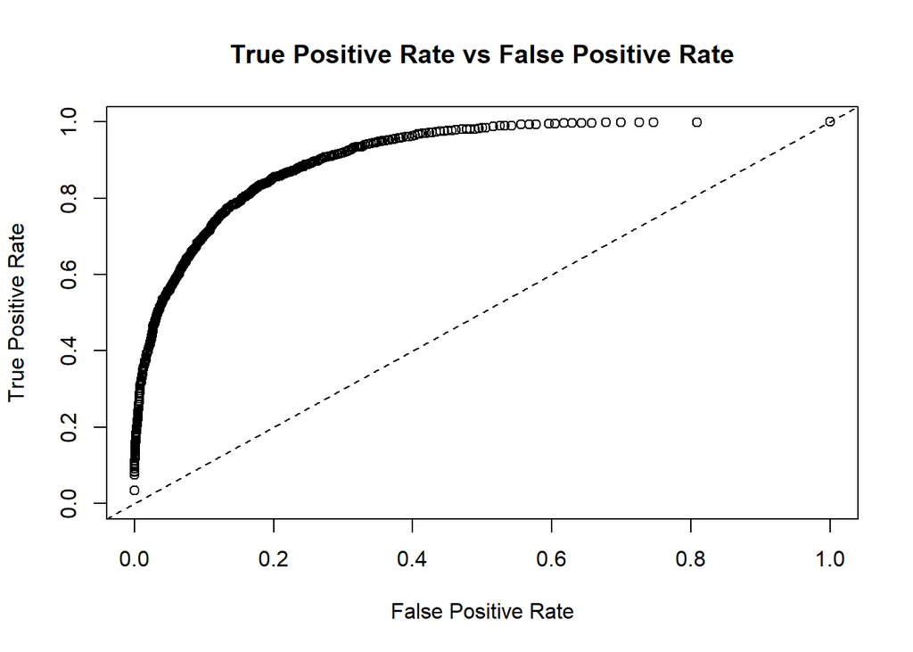

```r
plot(h2o.performance(md, dx_test), type = "roc")
```

```r
system.time({
md1 <- h2o.deeplearning(x = Xnames, y = "income", training_frame = dx_train, validation_frame = dx_valid,
activation = "Rectifier", hidden = c(50,50,50,50), input_dropout_ratio = 0.2,
epochs = 100, stopping_rounds = 2, stopping_metric = "AUC", stopping_tolerance = 0)})
```

```
##    user  system elapsed
##    0.33    0.00   24.86
```

```r
h2o.performance(md1, dx_test)@metrics$AUC
```

```
## [1] 0.9141719
```

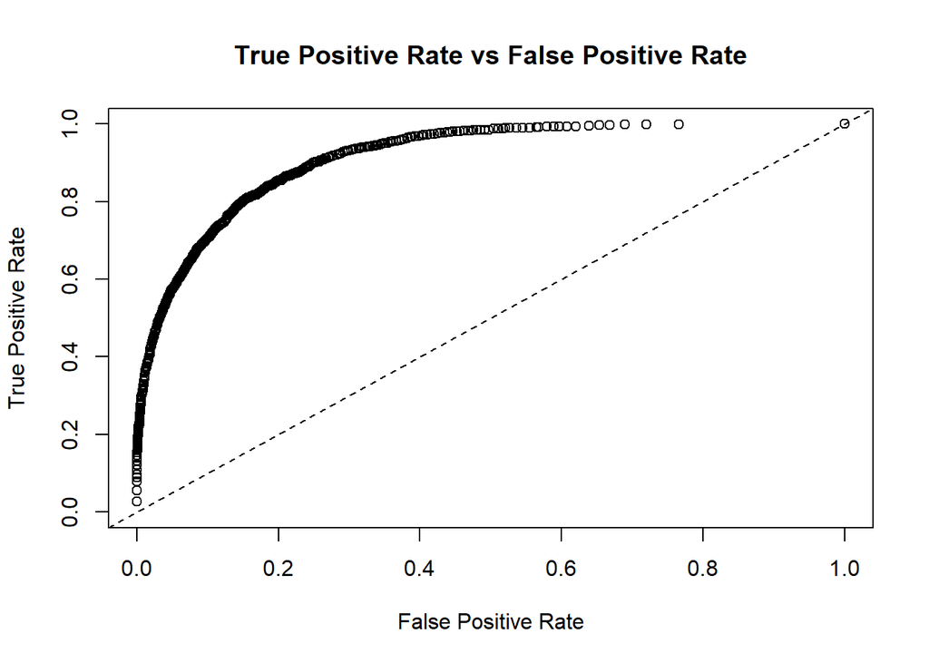

```r
plot(h2o.performance(md1, dx_test), type = "roc")
```

The third model.

```r
system.time({
md2 <- h2o.deeplearning(x = Xnames, y = "income", training_frame = dx_train, validation_frame = dx_valid,
activation = "Rectifier", hidden = c(50,50,50,50),
epochs = 100, stopping_rounds = 2, stopping_metric = "AUC", stopping_tolerance = 0)})
```

```
##    user  system elapsed
##    0.25    0.00   17.98
```

```r
h2o.performance(md2, dx_test)@metrics$AUC
```

```
## [1] 0.9123265
```

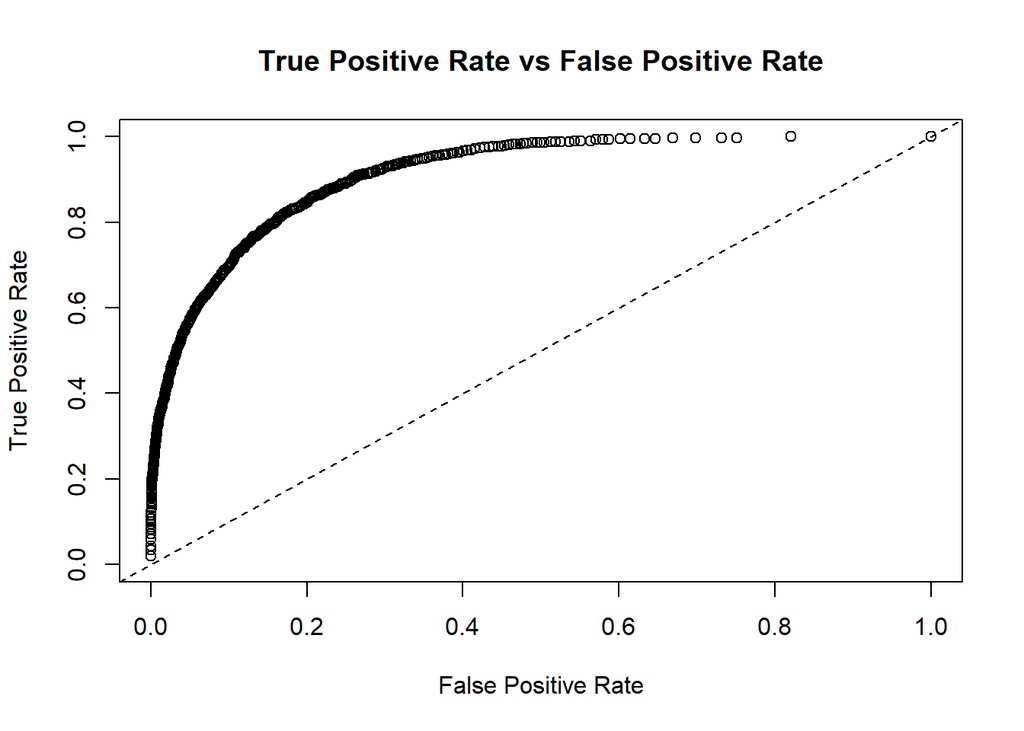

```r
plot(h2o.performance(md2, dx_test), type = "roc")
```

The forth model.

```r
system.time({
md3 <- h2o.deeplearning(x = Xnames, y = "income", training_frame = dx_train, validation_frame = dx_valid,
activation = "Rectifier", hidden = c(20,20),
epochs = 100, stopping_rounds = 2, stopping_metric = "AUC", stopping_tolerance = 0)})
```

```
##    user  system elapsed
##    0.21    0.02    7.68
```

```r
h2o.performance(md3, dx_test)@metrics$AUC
```

```
## [1] 0.9103791
```

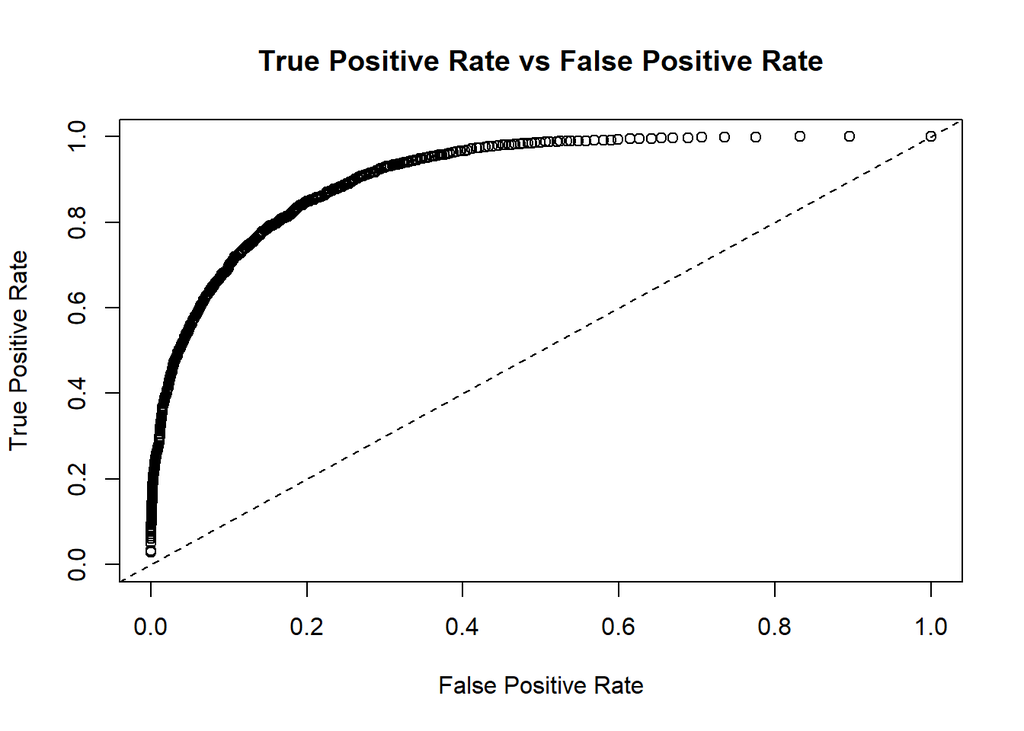

```r
plot(h2o.performance(md3, dx_test), type = "roc")
```

The fifth model.

```r
system.time({
md5 <- h2o.deeplearning(x = Xnames, y = "income", training_frame = dx_train, validation_frame = dx_valid,
activation = "Rectifier", hidden = c(5),
epochs = 100, stopping_rounds = 2, stopping_metric = "AUC", stopping_tolerance = 0)})
```

```
##    user  system elapsed
##    0.14    0.00    2.85
```

```r
h2o.performance(md5, dx_test)@metrics$AUC
```

```
## [1] 0.9119318
```

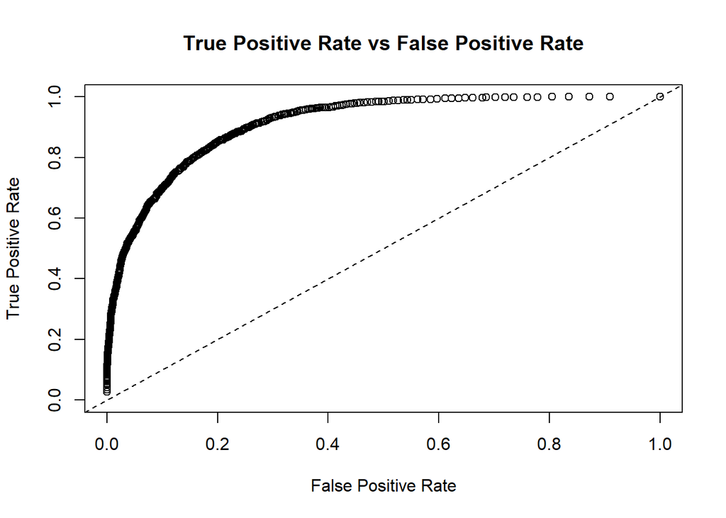

```r
plot(h2o.performance(md5, dx_test), type = "roc")
```

The sixth model.

```r
system.time({
md7 <- h2o.deeplearning(x = Xnames, y = "income", training_frame = dx_train, validation_frame = dx_valid,
activation = "Rectifier", hidden = c(200,200), l1 = 1e-5, l2 = 1e-5,
epochs = 100, stopping_rounds = 2, stopping_metric = "AUC", stopping_tolerance = 0)})
```

```
##    user  system elapsed
##    0.19    0.00   25.56
```

```r
h2o.performance(md7, dx_test)@metrics$AUC
```

```
## [1] 0.9086597
```

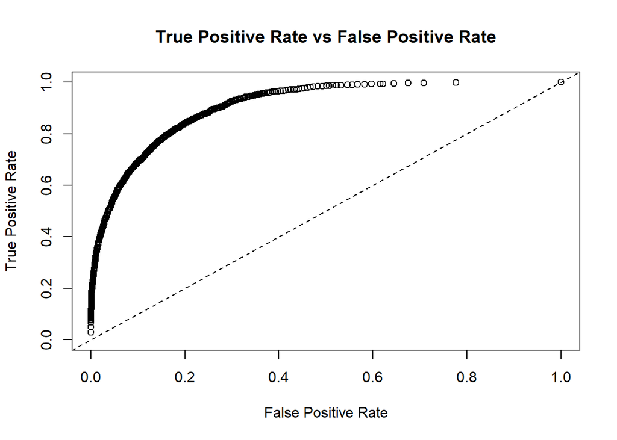

```r
plot(h2o.performance(md7, dx_test), type = "roc")
```

The 7th model.

```r
system.time({
md8 <- h2o.deeplearning(x = Xnames, y = "income", training_frame = dx_train, validation_frame = dx_valid,
activation = "Rectifier", hidden = c(200,200),
rho = 0.95, epsilon = 1e-06,  ## default:  rho = 0.99, epsilon = 1e-08
epochs = 100, stopping_rounds = 2, stopping_metric = "AUC", stopping_tolerance = 0)})
```

```
##    user  system elapsed
##    0.28    0.00   27.80
```

```r
h2o.performance(md8, dx_test)@metrics$AUC
```

```
## [1] 0.9063017
```

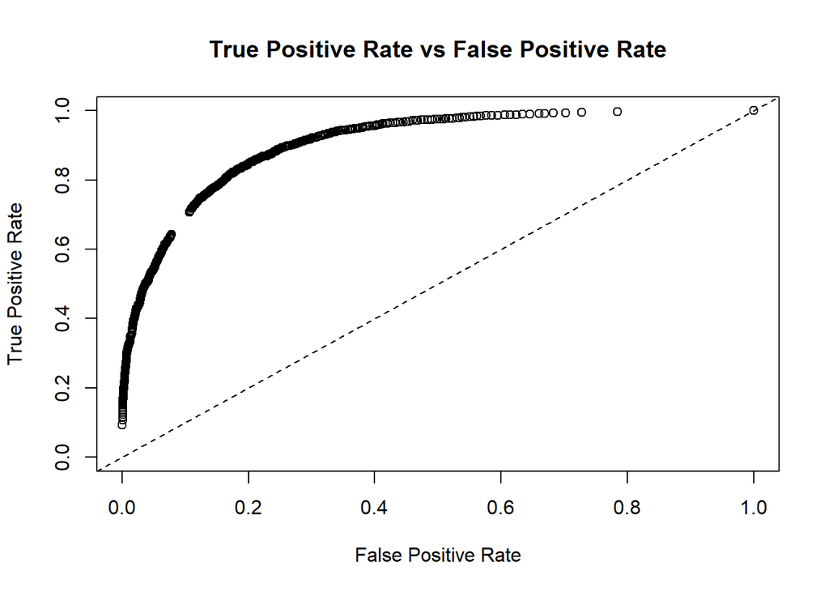

```r
plot(h2o.performance(md8, dx_test), type = "roc")
```

The 8th model.

```r
system.time({
md11 <- h2o.deeplearning(x = Xnames, y = "income", training_frame = dx_train, validation_frame = dx_valid,
activation = "Rectifier", hidden = c(200,200),
rho = 0.999, epsilon = 1e-06,  ## default:  rho = 0.99, epsilon = 1e-08
epochs = 100, stopping_rounds = 2, stopping_metric = "AUC", stopping_tolerance = 0)})
```

```
##    user  system elapsed
##    0.20    0.00   19.81
```

```r
h2o.performance(md11, dx_test)@metrics$AUC
```

```
## [1] 0.9066439
```

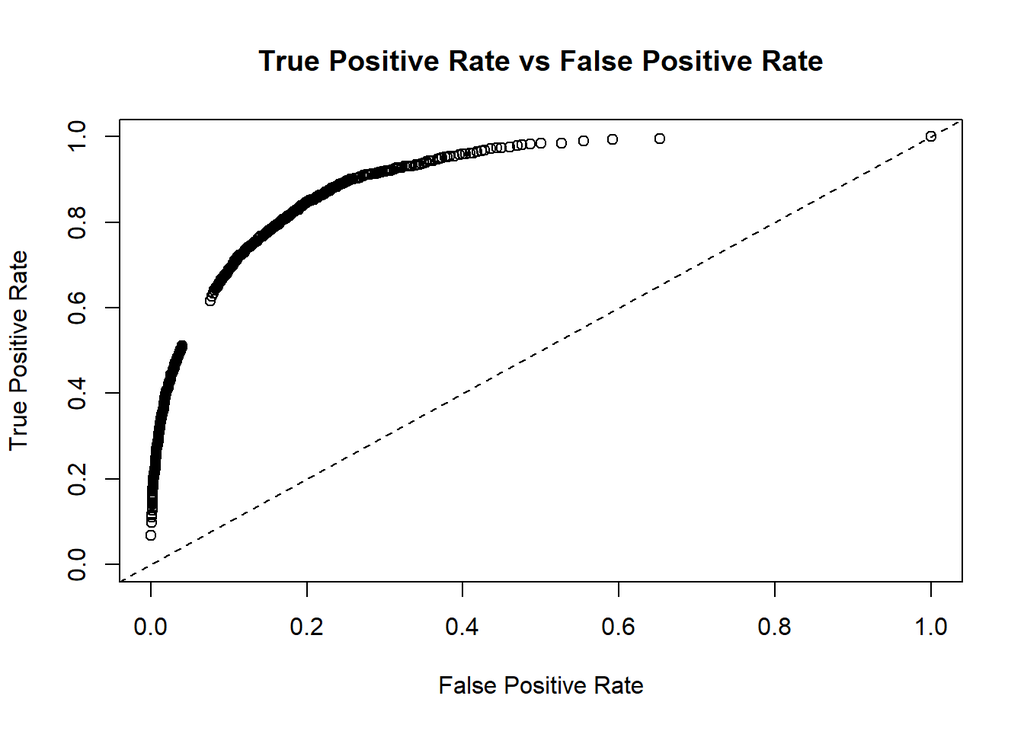

```r
plot(h2o.performance(md11, dx_test), type = "roc")
```

The 9th model.

```r
system.time({
md13 <- h2o.deeplearning(x = Xnames, y = "income", training_frame = dx_train, validation_frame = dx_valid,
activation = "Rectifier", hidden = c(200,200),
adaptive_rate = FALSE, ## default: rate = 0.005, rate_decay = 1, momentum_stable = 0,
epochs = 100, stopping_rounds = 2, stopping_metric = "AUC", stopping_tolerance = 0)})
```

```
##    user  system elapsed
##    0.13    0.02   21.44
```

```r
h2o.performance(md13, dx_test)@metrics$AUC
```

```
## [1] 0.9113822
```

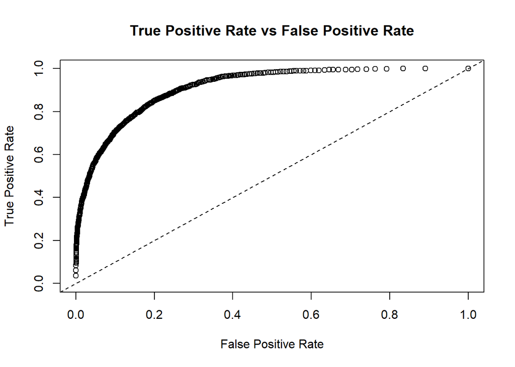

```r
plot(h2o.performance(md13, dx_test), type = "roc")
```

The 10th model.

```r
system.time({
md14 <- h2o.deeplearning(x = Xnames, y = "income", training_frame = dx_train, validation_frame = dx_valid,
activation = "Rectifier", hidden = c(200,200),
adaptive_rate = FALSE, rate = 0.001, momentum_start = 0.5, momentum_ramp = 1e5, momentum_stable = 0.99,
epochs = 100, stopping_rounds = 2, stopping_metric = "AUC", stopping_tolerance = 0)})
```

```
##    user  system elapsed
##    0.26    0.02   59.00
```

```r
h2o.performance(md14, dx_test)@metrics$AUC
```

```
## [1] 0.9127983
```

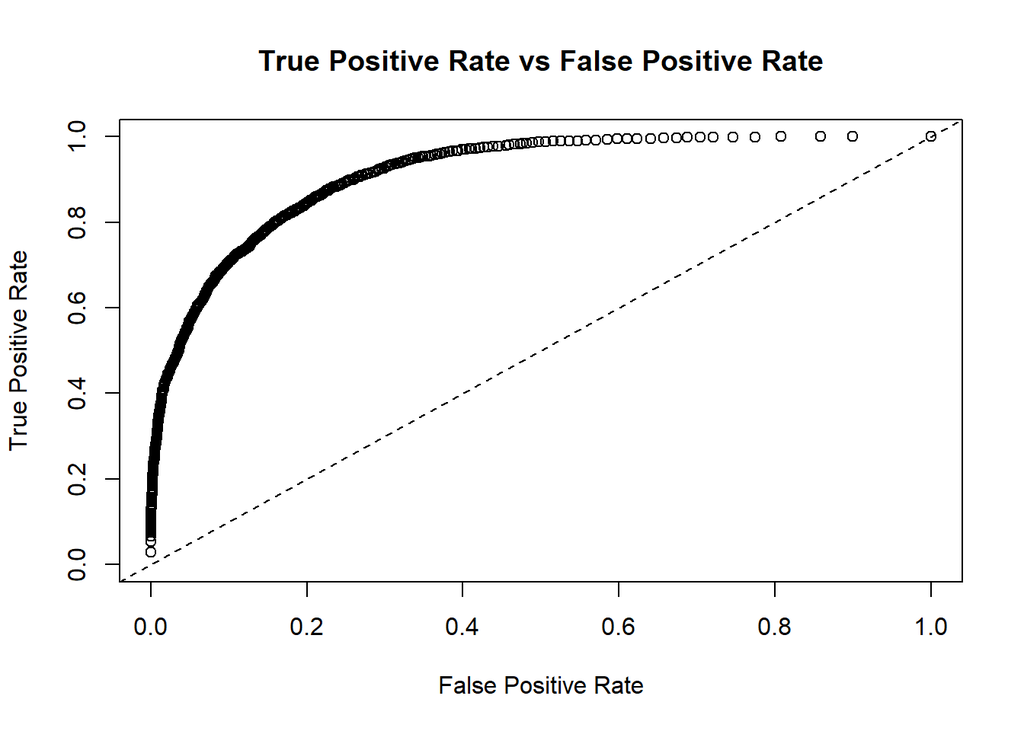

```r
plot(h2o.performance(md14, dx_test), type = "roc")
```

The 11th model.

```r
system.time({
md18 <- h2o.deeplearning(x = Xnames, y = "income", training_frame = dx_train, validation_frame = dx_valid,
activation = "Rectifier", hidden = c(200,200),
adaptive_rate = FALSE, rate = 0.01, rate_annealing = 1e-05,
momentum_start = 0.5, momentum_ramp = 1e5, momentum_stable = 0.9,
epochs = 100, stopping_rounds = 2, stopping_metric = "AUC", stopping_tolerance = 0)})
```

```
##    user  system elapsed
##    0.18    0.01   24.34
```

```r
h2o.performance(md18, dx_test)@metrics$AUC
```

```
## [1] 0.9144996
```

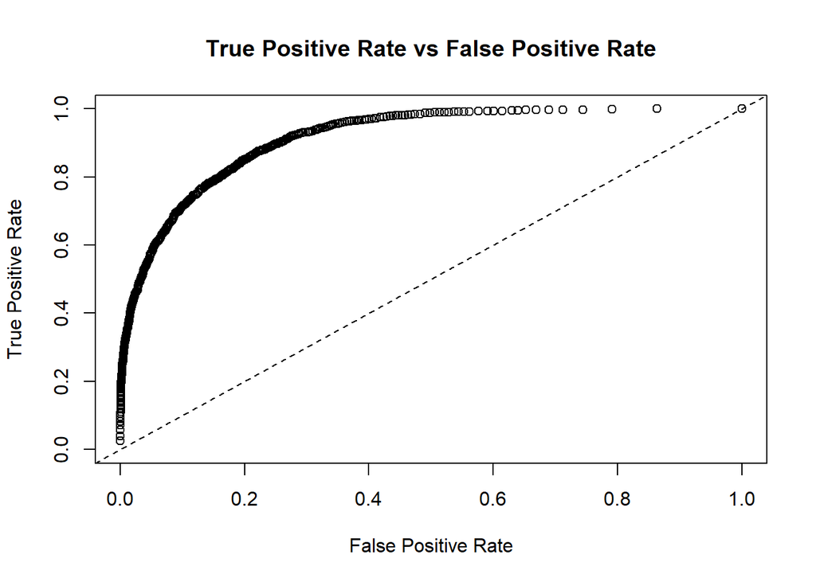

```r
plot(h2o.performance(md18, dx_test), type = "roc")
```

###### These models all have auc higher than 0.9, which means that the accuracy of the prediction is great. We use the auc to check for goodness. The ROC curve shows the true pos. rate vs. the false pos. rate. (known as sensitivity and specificity, from [wikipedia](https://en.wikipedia.org/wiki/Sensitivity_and_specificity))

## Ensembling various models

#### Playing with the parameters.

The first model.

```r
new_split <- h2o.splitFrame(adultdata, ratios = 0.7, seed = 123)
new_train <- new_split[[1]]
new_test <- new_split[[2]]
Newnames <- setdiff(names(new_train),"income")
system.time({
mdev1 <- h2o.glm(x = Xnames, y = "income", training_frame = dx_train,
family = "binomial", alpha = 1, lambda = 0,
seed = 123,nfolds = 5, fold_assignment = "Modulo", keep_cross_validation_predictions = TRUE)})
```

```
##    user  system elapsed
##    0.10    0.00    1.44
```

```r
h2o.auc(h2o.performance(mdev1, dx_test))
```

```
## [1] 0.9088348
```

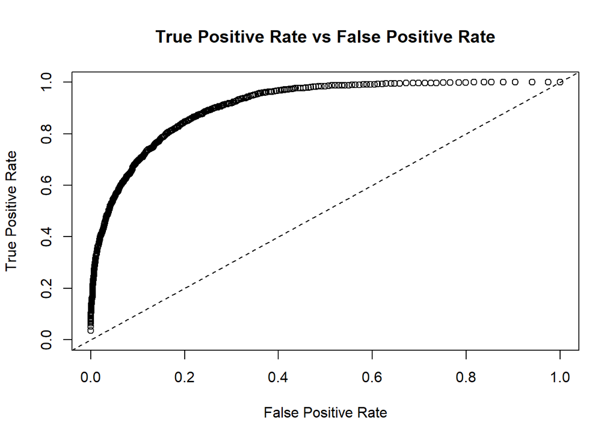

```r
plot(h2o.performance(mdev1, dx_test), type = "roc")
```

The second model.

```r
system.time({
mdev2 <- h2o.randomForest(x = Xnames, y = "income", training_frame = dx_train,
ntrees = 300, seed = 123,
nfolds = 5, fold_assignment = "Modulo", keep_cross_validation_predictions = TRUE)})
```

```
##    user  system elapsed
##    0.21    0.01   61.36
```

```r
h2o.auc(h2o.performance(mdev2, dx_test))
```

```
## [1] 0.9181677
```

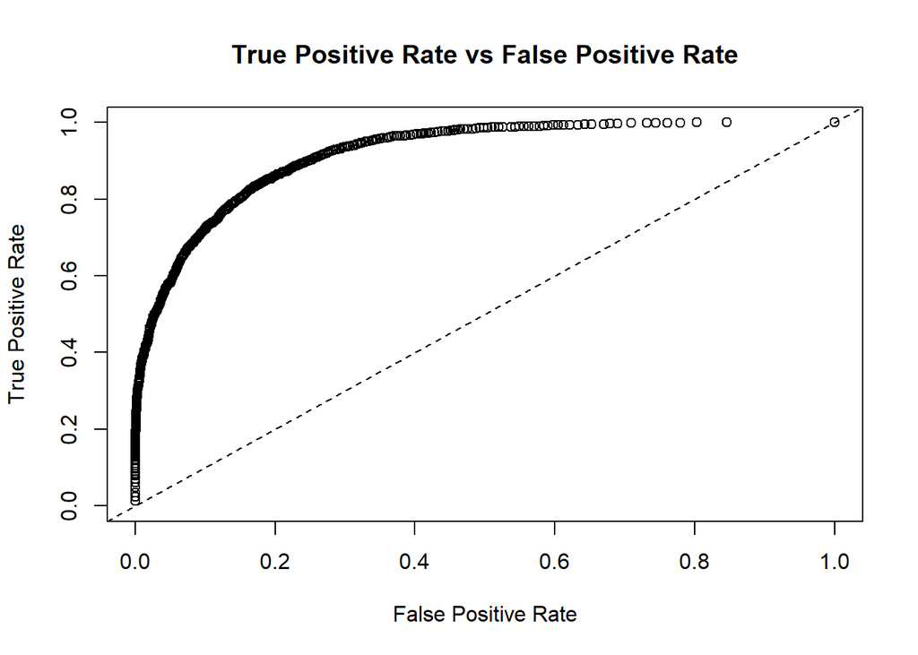

```r
plot(h2o.performance(mdev2, dx_test), type = "roc")
```

The third model.

```r
system.time({
mdev3 <- h2o.gbm(x = Xnames, y = "income", training_frame = dx_train, distribution = "bernoulli", ntrees = 200, max_depth = 10, learn_rate = 0.1,
nbins = 100, seed = 123,
nfolds = 5, fold_assignment = "Modulo", keep_cross_validation_predictions = TRUE)})
```

```
##    user  system elapsed
##    0.11    0.00   26.49
```

```r
h2o.auc(h2o.performance(mdev3, dx_test))
```

```
## [1] 0.923805
```

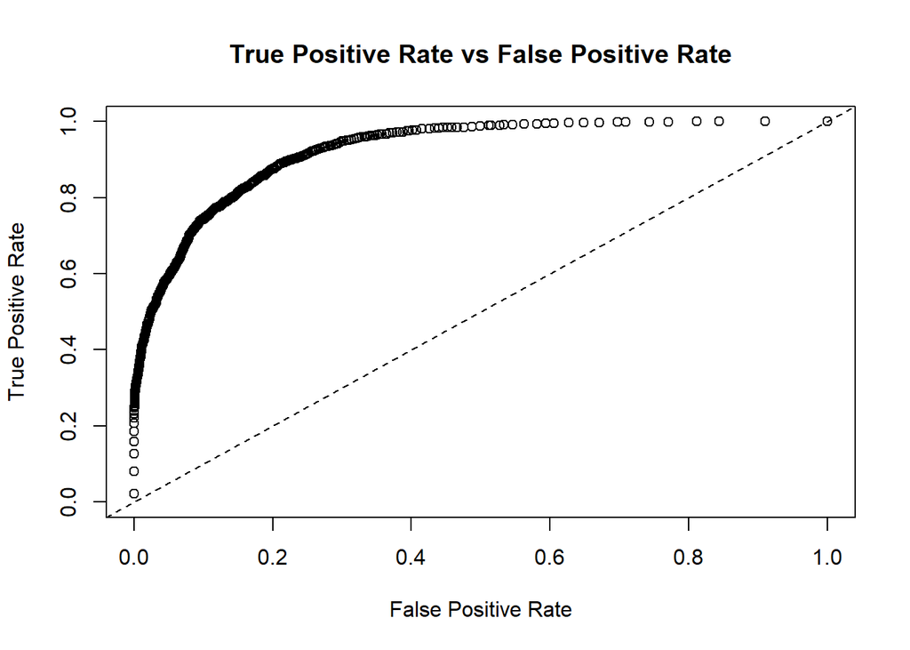

```r
plot(h2o.performance(mdev3, dx_test), type = "roc")
```

The forth model.

```r
system.time({
mdev4 <- h2o.deeplearning(x = Xnames, y = "income", training_frame = dx_train,
epochs = 5, seed = 123,
nfolds = 5, fold_assignment = "Modulo", keep_cross_validation_predictions = TRUE)})
```

```
##    user  system elapsed
##    0.27    0.00   30.73
```

```r
h2o.auc(h2o.performance(mdev4, dx_test))
```

```
## [1] 0.9122434
```

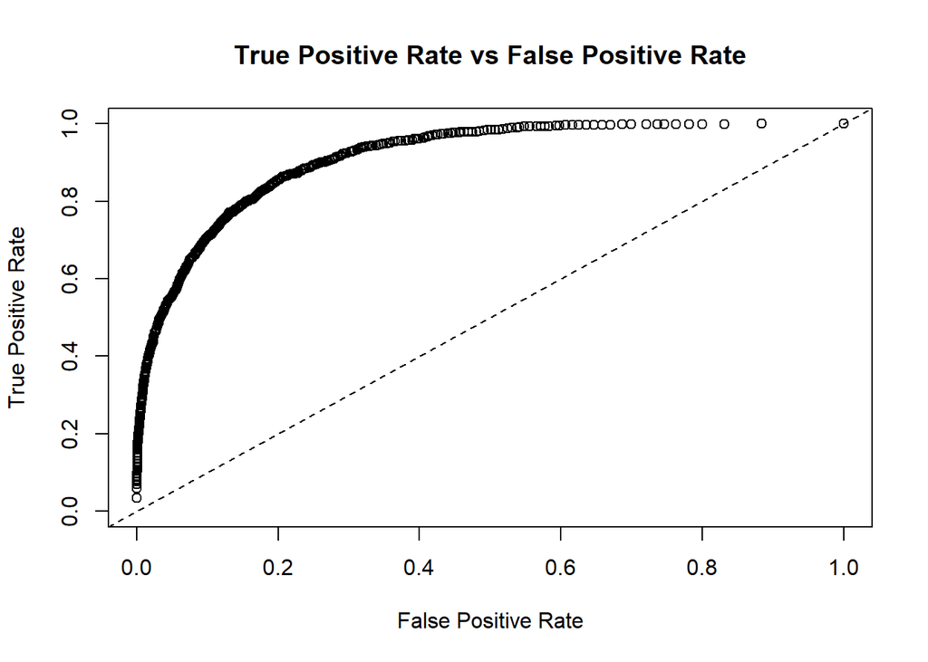

```r
plot(h2o.performance(mdev4, dx_test), type = "roc")
```

The fifth model.

```r
md_ens <- h2o.stackedEnsemble(x = Xnames, y = "income", training_frame = dx_train,
base_models = list(mdev1@model_id, mdev2@model_id, mdev3@model_id, mdev4@model_id))
h2o.auc(h2o.performance(md_ens, dx_test))
```

```
## [1] 0.9237784
```

The coefficients table of ensembling various models.

```r
h2o.getModel(md_ens@model$metalearner$name)@model$coefficients_table
```

```
## Coefficients: glm coefficients
##                                     names coefficients
## 1                               Intercept    -3.261503
## 2          GLM_model_R_1496823826681_2335     1.437944
## 3          DRF_model_R_1496823826681_2355     2.109659
## 4          GBM_model_R_1496823826681_2842     2.478759
## 5 DeepLearning_model_R_1496823826681_3323     0.526879
##   standardized_coefficients
## 1                 -1.724215
## 2                  0.411278
## 3                  0.622901
## 4                  0.808782
## 5                  0.162780
```

## Comparing the system time.

For all the models above, the auc looks pretty good that most of them are over 0.8. But the system time are very different. Below is a table that lists some models using different methods, with system time and auc values.

[output not shown]